# L02 Group Comparison

Marco Kühne

25 April 2022

# Learning Goals

- Conceptual Skills: What makes a good comparison. Never use pie charts.
- Data Skills:
  - R Basics: Install and load a package. Load Stata files into R.
  - Data Manipulation: `tidyverse` language (`glimpse()`, `count()`, `filter()`, `summarise()`).
  - Data Visualization: Pie chart and bar plot.

Social sciences is about the study of human beings and their interactions. As such, we frequently want to compare two or more groups of human beings, organizations, teams, countries, etc., with each other to see whether they are similar or different from each other. Sometimes we also want to track individuals over time and see how they may have changed in some way or other. In short, comparing groups is an essential technique to make inferences and helps us better understand the diversity surrounding us.

# Story Telling

Groups can be compared via **numeric figures** or **graphical instruments**. Numeric summaries can be the mean, median or mode. But it can be as simple as a percentage or proportion. A graphical representation can be a boxplot, histogram or density curve. Note that certain calculations and visualizations only make sense for continuous variables (cf. scale of measurements).

Most data visualization is done for the purpose of communication. We have an insight about a dataset, and we have a potential audience, and we would like to convey our insight to our audience. To communicate our insight successfully, we will have to present the audience with a clear and exciting story.

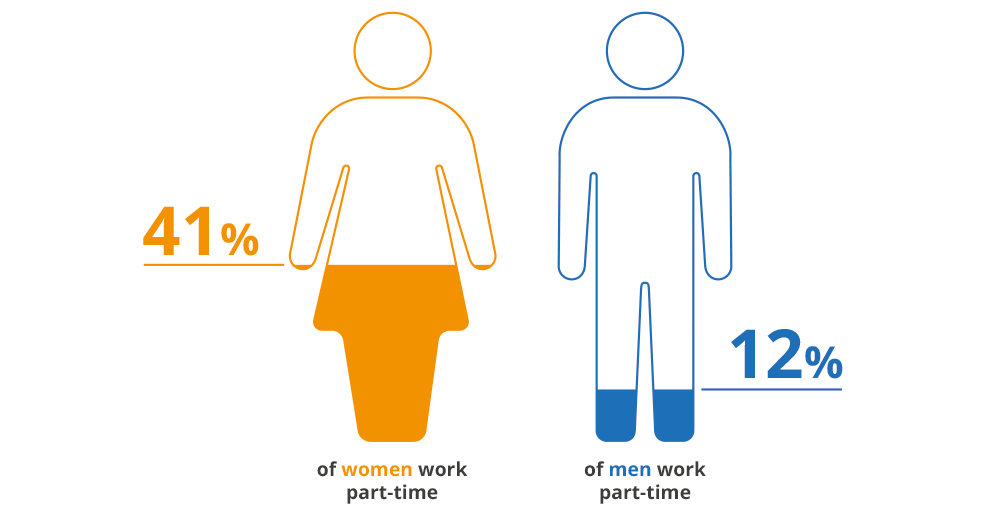

Figure 1: Possible gender difference in working parttime.

# Comparability

What makes a good comparison? Before we can jump into group comparisons, we need to make ourselves aware of whether our groups can be compared in the first place. We are looking at the characteristics of our groups. Some commonly considered features include:

**Size: Are the groups about equally large?**

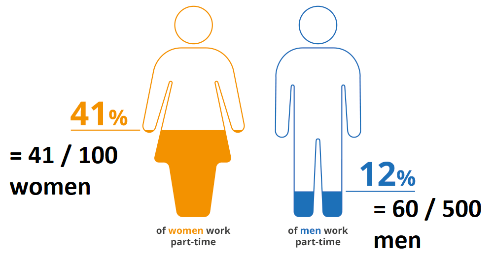

**Time: Was the data collected around the same time?**

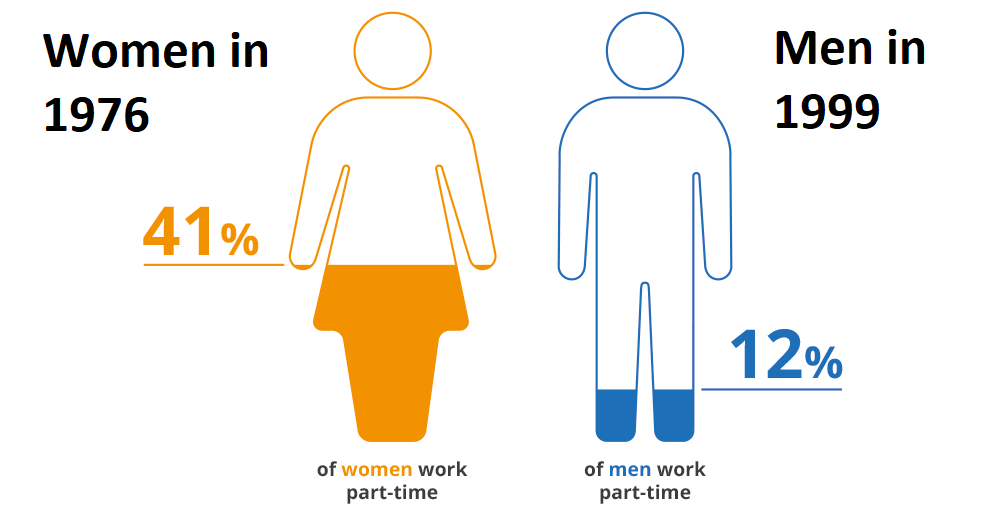

**Exogenous variables: Is the distribution of characteristics we are not interested in approximately the same across groups?**

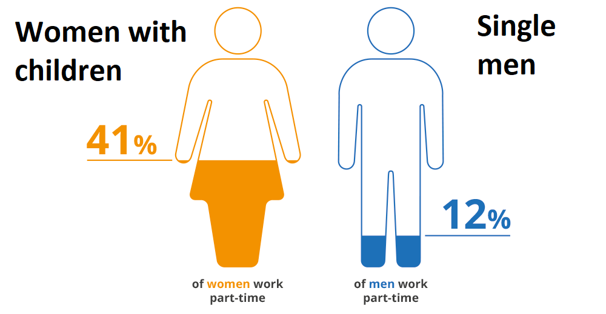

# SOEP Practice Data

The SOEP practice dataset is a highly simplified Stata practice dataset, which can be downloaded from the homepage of DIW Berlin (in German or English):

https://www.diw.de/en/diw_01.c.603154.en/soep_in_the_college_classroom.html

There are two versions (years 2000-2004, 9 variables and years 2015-2019, 15 variables). They contain multiple observations per person over time. Each row is uniquely identified by a year-id combination (long format panel data).

## Loading the Data

In the following a temporary file is created to store the .zip information from SOEP practice data. Thus there is no need to manually click and download a file and set the correct path on the computer.

```r
# load package
library(haven)

# tempfile returns a vector of character strings which can be used as names for temporary files.
temp <- tempfile()
# download the .zip file to your temporary file location
download.file("https://www.diw.de/documents/dokumentenarchiv/17/diw_01.c.412698.de/soep_lebensz_en.zip",temp)
# type temp in your console to get this file name
# you can open your temporary files on Windows: %userprofile%\AppData\Local\Temp
# you may search for the file name

# load Stata data with haven package
soep <- read_dta(unz(temp, "soep_lebensz_en.dta"))

# unlink deletes the file(s) or directories specified by x.
unlink(temp)
```

If data is somewhere else, you need to specify the exact path (relative or absolute path) to the data. If you use `haven` (or any other package) for the first time, you have to install (e.g. via a command `install.packages("haven")`). You can also install and check packages in the right lower panel (cf. “packages”).

## Inspect the Data

The SOEP practice dataset 1 consists of a total of 9 original variables and 12,922 measurements. We can see 9 variables as columns with the `glimpse()` function. The first two variable *(id, year) are identifier*. The panel data is in *long format, i.e. every row is a person-year combination*. It covers five time points. The last two variables are standardized versions (satisfaction and health). Actually we have 5 variables to analyze.

```r
library(tidyverse)
glimpse(soep)
```

```
## Rows: 12,922
## Columns: 9
## $ id         <dbl> 312, 399, 399, 457, 457, 457, 748, 761, 761, 1044, 1044, 10~
## $ year       <dbl> 2004, 2000, 2001, 2000, 2002, 2004, 2000, 2000, 2001, 2000,~
## $ sex        <dbl+lbl> 1, 0, 0, 0, 0, 0, 1, 1, 1, 0, 0, 0, 0, 0, 1, 1, 1, 1, 1~
## $ education  <dbl> NA, 12.0, 12.0, 18.0, 18.0, 18.0, 14.0, 16.0, 16.0, 14.0, 1~
## $ no_kids    <dbl> 1, 1, 1, 0, 0, 0, 0, 2, 2, 1, 1, 1, 1, 1, 0, 0, 0, 0, 0, 2,~
## $ health_org <dbl+lbl> 4, 4, 4, 3, 3, 2, 3, 3, 3, 4, 3, 4, 4, 4, 2, 2, 2, 1, 2~
## $ satisf_org <dbl+lbl>  7,  8,  9,  8,  7,  4,  5,  7,  7,  5,  7,  8,  6,  7,~
## $ health_std <dbl> 0.5670103, 0.5670103, 0.5670103, -0.4639175, -0.4639175, -1~
## $ satisf_std <dbl> -0.09090909, 0.47727272, 1.04545450, 0.47727272, -0.0909090~
```

First, let’s check the consecutive time points. The `count()` function provides the number of occurrences for values of a variables.

```r
soep %>%
  count(year)
```

```
## # A tibble: 5 x 2
##    year     n
##   <dbl> <int>
## 1  2000  3198
## 2  2001  2690
## 3  2002  2485
## 4  2003  2299
## 5  2004  2250
```

We observe a decline in observations over time. People drop out of the survey for various reasons (**panel attrition**). SOEP regularly adds refreshment samples to compensate for this. Sometimes we miss data in between years. Person number 457 participated in 2000, 2002 and 2004:

```r
soep %>%
  filter(id == 457)
```

```
## # A tibble: 3 x 9
##      id  year       sex education no_kids       health_org satisf_org health_std
##   <dbl> <dbl> <dbl+lbl>     <dbl>   <dbl>        <dbl+lbl>  <dbl+lbl>      <dbl>
## 1   457  2000  0 [male]        18       0 3 [satisfactory] 8 [8 Sati~     -0.464
## 2   457  2002  0 [male]        18       0 3 [satisfactory] 7 [7 Sati~     -0.464
## 3   457  2004  0 [male]        18       0 2 [poor]         4 [4 Sati~     -1.49
## # ... with 1 more variable: satisf_std <dbl>
```

Person 457 was not available in the year 2001 for some reason.

## Stata information

The `haven` package tries to keep as much information from the Stata source as possible. This can be helpful because we can look up background information, e.g. about coding.

```r
attr(soep$sex, "labels")
```

```
##   male female
##      0      1
```

## Summary statistics

Now let’s have a look at **summary statistics** for the dataset. The `stargazer` package (with `type="text"`) displays number of observations, mean, standard deviation, min, max and percentiles to the console or markdown file (it produces a .tex table by default). `stargazer` requires a dataframe as input. `haven` created a tibble from the Stata .dta file. Finally, we select all variables but the first two, since they are identifier and any calculation, e.g. the mean of personal IDs, does not make much sense here.

```r
library(stargazer)
stargazer(as.data.frame(soep)[,(3:9)], type="text")
```

```
##
## =================================================================
## Statistic    N     Mean  St. Dev.  Min   Pctl(25) Pctl(75)  Max
## -----------------------------------------------------------------
## sex        12,922 0.539   0.499     0       0        1       1
## education  11,454 11.874  2.469   7.000   10.500   13.000  18.000
## no_kids    12,016 0.647   0.931   0.000   0.000    1.000   3.000
## health_org 12,907 3.455   0.973   1.000   3.000    4.000   5.000
## satisf_org 12,922 7.156   1.762     0       6        8       10
## health_std 12,907 0.005   1.003   -2.526  -0.464   0.567   1.598
## satisf_std 12,922 -0.002  1.001   -4.068  -0.659   0.477   1.614
## -----------------------------------------------------------------
```

The mean of `sex` is 0.539. What does it tell you?

## Missing data

Check out the first `glimpse()` table. Have you noticed the value `NA` in `education`? **NA** stand for non available and is the indicator for **missing data in R**. We ask for a table count of all values in the data that are either missing or not missing.

```r
table(is.na(soep))
```

```
##
##  FALSE   TRUE
## 113894   2404
```

One option is substituting values (e.g. the mean) for missing cells (**imputation**). The alternative, for simplicitiy, is removing all rows which contain a missing value in any column. This is called a **complete case analysis**.

```r
soep_no_na <- soep %>% filter(complete.cases(.))
```

## Standardization

Look again at the `glimpse()` output or `stargazer()` table. Notice two versions of satisfaction and health, i.e. `satisf_org` and `satisf_std` which represent satisfaction on the original scale (from 0 to 10) and a *standardized* version of satisfaction. Health is ranging from 1 to 5. How can we compare the mean of satisfaction and health?

In statistics, **standardization** is the process of putting different variables on the same scale. This process allows you to compare scores between different types of variables (compare apples with apples instead of apples with bananas). Typically, to standardize variables, you calculate the mean and standard deviation for a variable (cf. z-score). Then, for each observed value of the variable, you subtract the mean and divide by the standard deviation.

Consequently, standardized variables have a mean of 0 and a standard deviation of 1.

```r
soep_no_na %>%
  summarise(across(c(satisf_std, health_std), list(mean, sd))) %>%
  `colnames<-`(c("mean of std. satis", "sd of std. satis",
                 "mean of std. health", "sd of std. health"))
```

```
## # A tibble: 1 x 4
##   `mean of std. satis` `sd of std. satis` `mean of std. health` `sd of std. hea~
##                  <dbl>              <dbl>                 <dbl>            <dbl>
## 1              0.00174               1.00               -0.0102            0.998
```

Here `summarise` is asked to apply the `mean()` and `sd()` function “across” the two columns `satisf_std` and `health_std`. The means are close to zero and the standard deviation is close to one. The minor differences result from our complete case analysis (we already dropped some cases which might have been used for the initial standardization).

# Never use pie charts

Pit charts are evil. Why? Check the *note* of the documentation of `pie()`:

```r
?pie()
```

*Pie charts are a very bad way of displaying information. The eye is good at judging linear measures and bad at judging relative areas. A bar chart or dot chart is a preferable way of displaying this type of data.*

*Cleveland (1985), page 264: “Data that can be shown by pie charts always can be shown by a dot chart. This means that judgements of position along a common scale can be made instead of the less accurate angle judgements.” This statement is based on the empirical investigations of Cleveland and McGill as well as investigations by perceptual psychologists.*

**Synthetic data for a graph.**

```r
# Create data for the graph.
x <- c(14, 62, 17, 53)
labels <- c("London", "New York", "Singapore", "Mumbai")
```

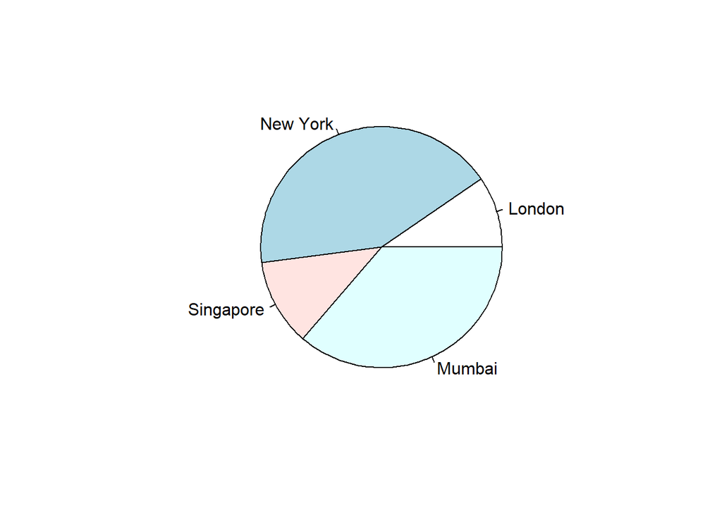

```r
# Plot the chart.
pie(x,labels)
```

**Do a barplot instead.**

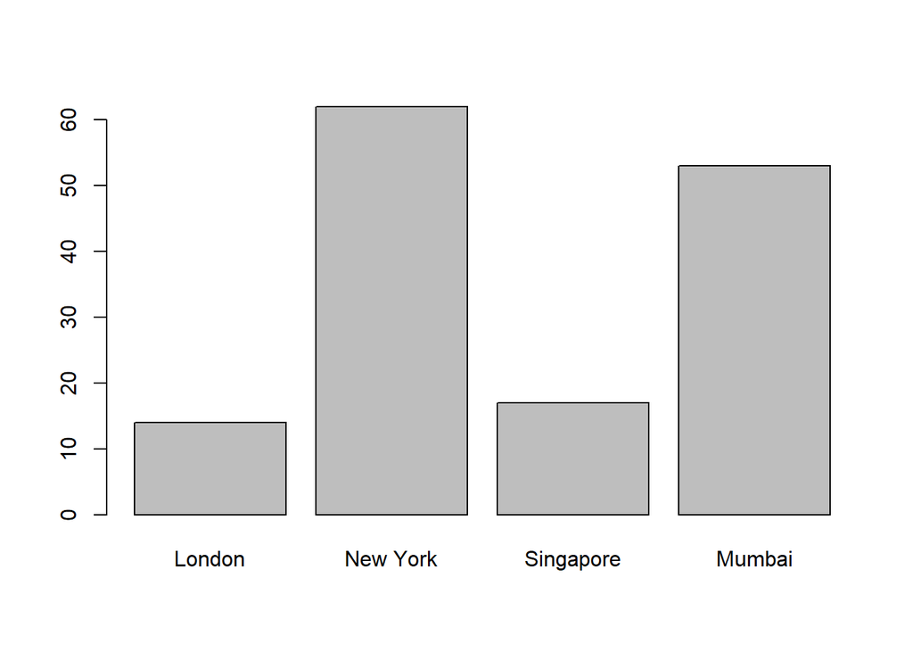

```r
# Plot the chart.
barplot(x, names.arg = labels)
```